# Linear_demand_supply slides

### Eco 100 diagrams

## Linear Demand and Supply Diagram

This is a jupyter notebook to generate a simple interactive supply and demand diagram using python and `ipywidgets` (interactive HTML widgets) to provide sliders and animations.

```
(200.0, array(200.))
```

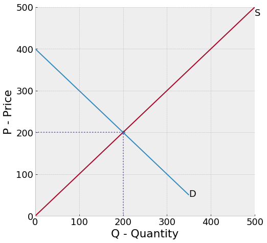

```python
mkt(A=400, b=1, F=0, c=1)
```

### interactive plot

On the next cell move the sliders in the next cell to shift Supply or Demand in or out

Note: this will not display unless you are running this on a jupyter server

```python
interact(mkt, A=(200,500,10),b=fixed(1),F=(0,300,10),c=fixed(1));
```

### Quantitative Restrictions

```
Pd = 350, Ps = 150, license rent = 200
CS = 11250, PS = 11250, rents = 30000, TS = 52500  DWL = 10000
```

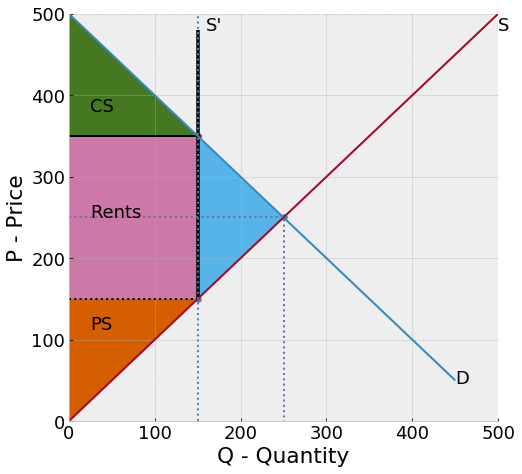

```python
qrplot(150);
```

```python
interact(qrplot, qr =(0,250,10));
```

End

#### Notes: the simple math behind the diagram

A demand curve tells us the quantity $Q$ that will be demanded of a good at any given price. This suggests a relationship of the form $Q(P)$, i.e. $Q$ as a function of $P$.

However, by historical convention economists have almost always drawn demand curves with quantity $Q$ on the horizontal axis and price $P$ on the vertical axis. For some this might suggest we are plotting a function of the form $P(Q)$. This is an 'inverse' demand function (the maximum price at which quantity Q will be demanded).

this of course corresponds to a Demand curve of the form $Q^D(P) = \frac{A}{b} - \frac{1}{b}P$

The (inverse) **supply curve** curve is of the form:

$$P^S(Q) = F + c \cdot Q$$

As will be seen later in the course the market supply curve is a marginal cost curve.

The market equilibrium price $P^e$ can be found where supply meets demand.

$$P^S(Q) = P^e = P^D(Q)$$

With the linear demand and supply system above we can easily solve for the market equilibrium quantity $Q^e$

which leads to:

$$Q^e = \frac{A-F}{c+b}$$

And the market equilibrium price $P^e$ is then easuily found from either $P^D(Q^e)$ or $P^S(Q^e)$

```python
!cd
```

```
G:\E\GitHub\Econ-Teach\intro
```